# Is education spending the solution to protecting children in Asian countries?

Kevin Yamada

**Introduction**

The goal of our analysis is to gain insights into child protection by observing their education completion rates. By drawing connections between social issues and education, we outline the problem and offer a solution by suggesting that spending more on education increases education completion rates which will potentially decrease issues such as child marriage, child labour, detention, adolescent birth rates, etc. For this article we use data from The State of the World’s Children 2024 Statistical Compendium provided by UNICEF and we focus on the statistic of Upper Secondary Education (USE) Completion Rate– the Canadian equivalent of a high school degree. We provide the justification in order to increase government spending on education with the goal of protecting children.

**Child Labour**

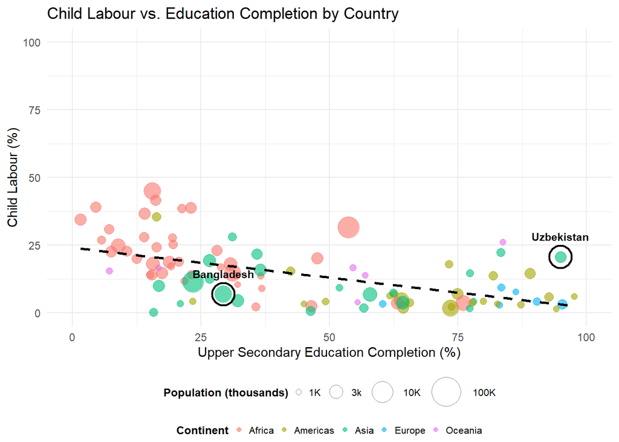

When posed with the question of what prevents students from completing their upper secondary education, one of the factors that inhibits students is an obligation to work. As children take on the responsibility to generate income, their available time to spend towards their education naturally decreases. UNICEF provides the child labour percentage rates of countires in 2023 which is plotted against the the USE Completion Rate with each plot point representing a country, as seen above. The plot shows a negative relationship between the two using the dotted trend line which affirms the intuition that higher child labour rates are accompanied by lower rates of completed education. The points have also been colored by continent for further insights into where the specific problem of child labour is most prevalent. The majority of countries on the left end of the plot are African with higher rates of child labour and lower USE Completion Rates and a large disparity within Asian countries is prevalent.

Note that not all countries are plotted above, only the ones that had complete data for Child Labour Rate and USE Completion Rate. That is why for this plot and the next Uzbekistan will serve as an example for high performance in USE Completion in Asia. Despite the trends, both countries seem to be outliers as Bangladesh sits below the trend line and Uzbekistan sits above. This means that Bangladesh has low child labor rates for its poor performance in USE Completion while Uzbekistan has high child labour rates for its high preformance in USE completion. This reminds us that this plot is not showing causality but simply the trend or relationship between the two factors.

It must be recognized that different countries with varying population sizes have different realities in which they operate. Larger populations have greater demands on their education systems which can lead to strain and poor support in endeavours of completion. These strains can be exacerbated by inadequate funding and limited resources. That is why each point has been adjusted by size to represent the relative population for each country.

**Child Marriage**

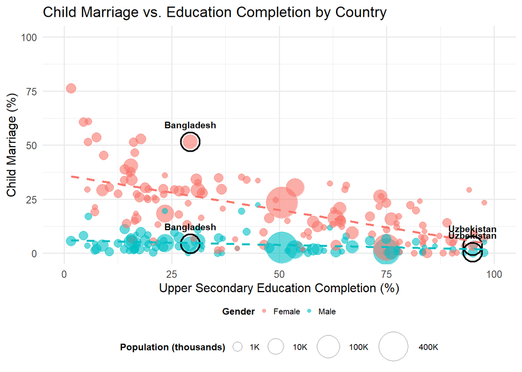

Besides the obligation to work, child marriages are another cultural duty that some children are upheld to. Along with marriage typically comes the responsibilities of starting a family and other cultural norms about what the role of a wedded person looks like. These roles can also be vastly different between men and women. A lot of the time, school becomes secondary to the needs of this new stage in life.

In the above plot, USE Completion is compared to Child Marriage Rates between the two genders. The trend line is present for each gender and the points are adjusted by size according to population sizes. Here a clear difference is apparent in the effect child marriage has on education completion between the two genders. For women, this relationship is evidently negative, higher marriage rates means lower USE Completion Rates. For men, this relationship is non-existent as the trend line lays flat. Not only does child marriage for men not effect their schooling but child marriage in men is a a rare issue since the trend line lies close to 0. This means there are very few cases of child marriage in men.

Looking at the counties of interest, we can see a large gap between genders for this social issue while in Uzbekistan the gap is smaller. This might suggest that countries with greater disparity in social issues dealing with gender may have lower performance in education completion.

**Adolescent Birth Rate**

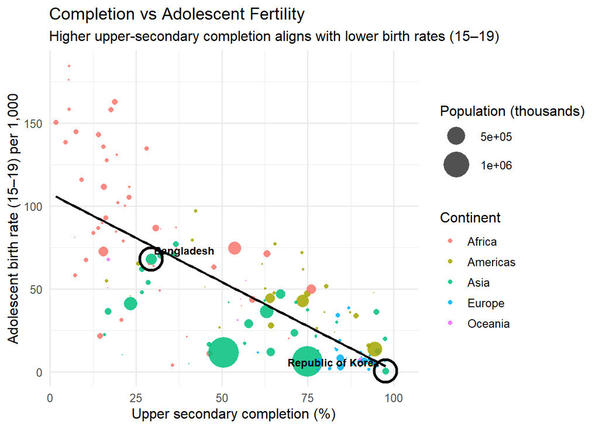

The colour encodings also help identify which continents overall require more attention and funding as African countries have a lower completion rate and higher adolescent fertility rate on average than European countries for example. The population encoding is to show a limitation because a country with more people must spend more given the same GDP so using size, we can draw more attention to the countries that require more attention because of this fact.

**A Potential Solution**

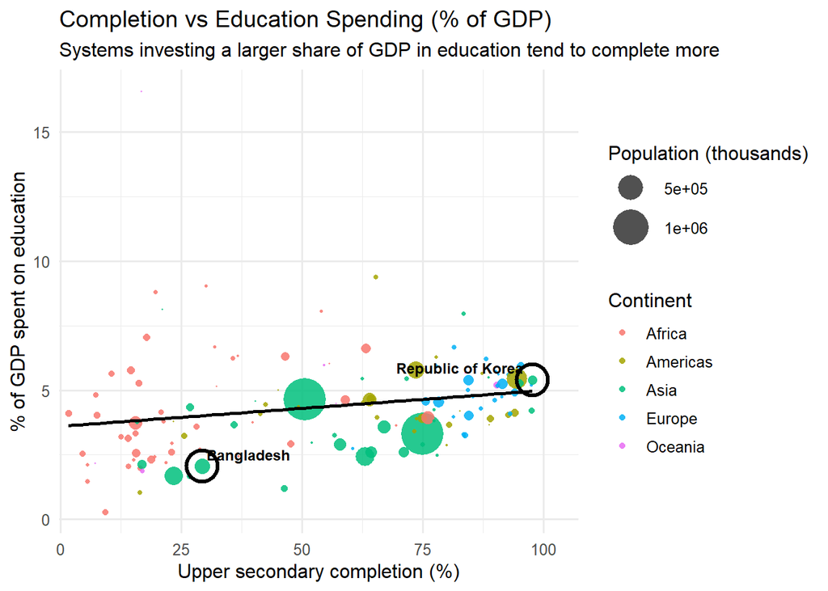

In conclusion, protecting adolescents starts with the classroom and by increasing effort in education expenditure, children can be kept away from work and given opportunities to pursue their dreams and aspirations. The data supports this as countries with higher completion often have a lower adolescent fertility rate, lower child labour rates, lower child marriage rates. Additionally, countries with a larger GDP dedicated to education tend to have a higher completion rate .